# Hufkens_Documentation

## 3. Growth and senescense do not happen at the same time (v11)

The remaining issues of the model seem to be: 1. the plant really repond to water very quickly and certainly not after 16 days; 2. in all previous versions, growth only takes place on one day (16-day after rainfall) with next day followed by senescense. This seems not to be a very optimal stratergy.

I then propose to change the separate growth and senescense: when water.avi is larger than the the et of the past several days (3 in the case below), there will be growth, otherwise it’s die back.

```r
if (water.avi[nm.day] > et[nm.day] * drought.expect) {
    # here growth and senesecense are separated
    g = 1
    d = 0
} else {
    g = 0
    d = 1
}

# # calculate plant cover
water.avi.norm <- water.avi[nm.day]/(swc.capacity - swc.wilt)  #plant will only respond to the water vailibility of the day
# plant cover
growth.vec[nm.day] <- g * f.growth * water.avi.norm * (1 - cover.pred.vec[nm.day -
    1]/cover.max)
senescence.vec[nm.day] <- d * f.sec * (1 - water.avi.norm)

cover.pred.vec[nm.day] <- cover.pred.vec[nm.day - 1] + growth.vec[nm.day] -
    senescence.vec[nm.day]

# calculate swc
evap.vec[nm.day] <- (1 - cover.pred.vec[nm.day - 1]) * (water.avi.norm)^2 *
    et[nm.day]
transp.vec[nm.day] <- f.extract * water.avi.norm * cover.pred.vec[nm.day]/cover.max

swc.vec[nm.day] <- swc.vec[nm.day - 1] + gcc.df$Rain[nm.day] - evap.vec[nm.day] -
    transp.vec[nm.day]
```

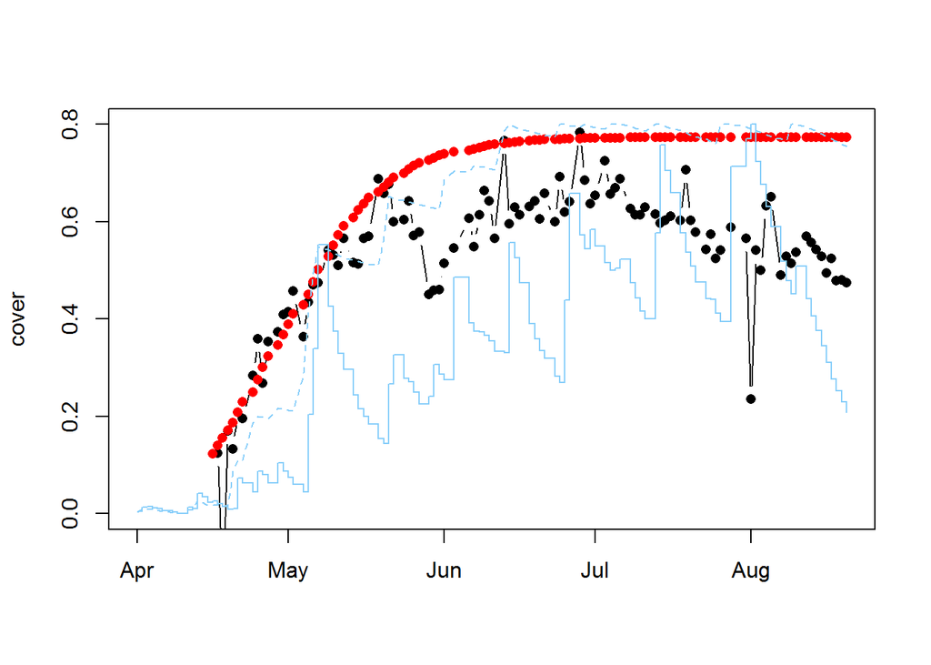

Fig 5. The issue of this v11 is that senescense never happens. That is because after a rain event, the swc never goes too low.

I then propose to change the timing of senescense to 1 day after rainfall.

```r
# check whether it have rained or not
rained.vec <- c()
rained.vec[1:day.lay] <- 0
for (i in (day.lay + 1):nrow(gcc.df)) {
    if (sum(gcc.df$Rain[(i - day.lay):i], na.rm = T) > 0) {
        rained.vec[i] <- 1
    } else {
        rained.vec[i] <- 0
    }
}

# set growth-g and senescense-d based on rain in previous days
if (rained.vec[nm.day] == 1) {
    g = 1
    d = 0
} else {
    g = 0
    d = 1
}

# # normalise water avilibility
water.avi.norm <- water.avi[nm.day]/(swc.capacity - swc.wilt)
# plant cover
g.value <- t.func(t.m[nm.day], f.t.opt, t.max)
growth.vec[nm.day] <- g * g.value * f.growth * water.avi.norm * (1 - cover.pred.vec[nm.day -
    1]/cover.max)
senescence.vec[nm.day] <- d * f.sec * (1 - water.avi.norm)  #* cover.pred.vec[nm.day-1] / cover.max

cover.pred.vec[nm.day] <- cover.pred.vec[nm.day - 1] + growth.vec[nm.day] -
    senescence.vec[nm.day]

# calculate swc
evap.vec[nm.day] <- (1 - cover.pred.vec[nm.day - 1]) * (water.avi.norm)^2 *
    et[nm.day]
transp.vec[nm.day] <- f.extract * water.avi.norm * cover.pred.vec[nm.day]/cover.max

swc.vec[nm.day] <- swc.vec[nm.day - 1] + gcc.df$Rain[nm.day] - evap.vec[nm.day] -
    transp.vec[nm.day]
```

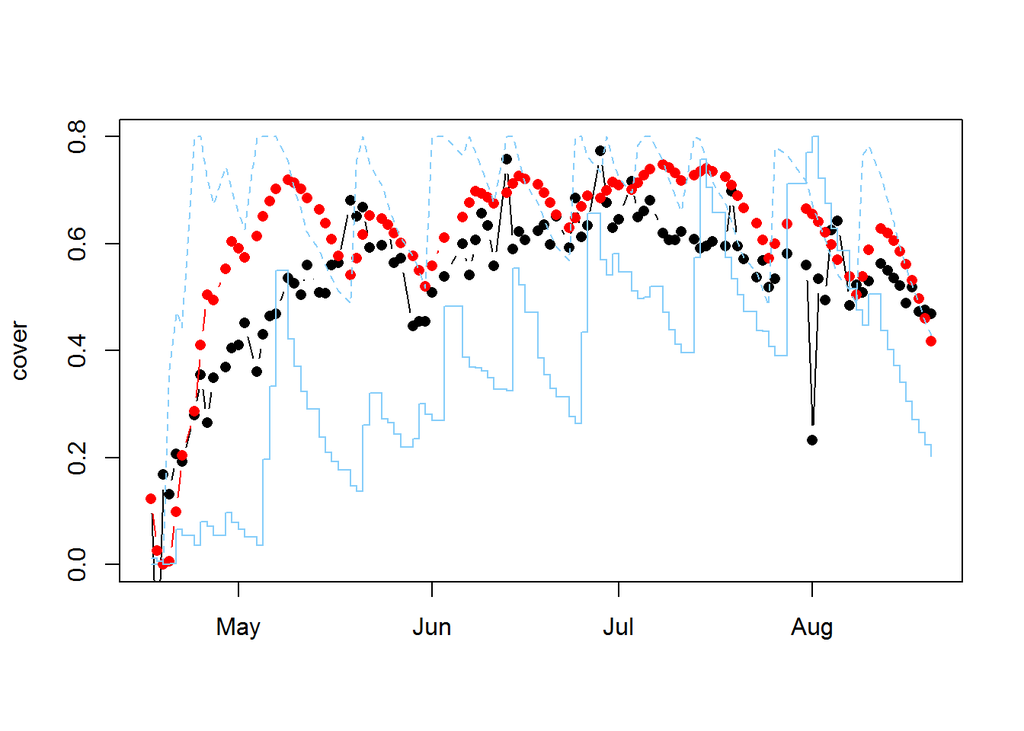

Fig 6. Forced senesece one day after each rainfall event. The dashed blue line is the predicted swc.

It helps and only misses some little dynamics. But note here I also changed the bucket size: now it’s assume that only the top 200mm of soil matters.